# CISC 610 50 A Fall Final Project - Mengdi Cheng

# Password Manager Using Hash Tables & Password Hashing

#### Student: Mengdi Cheng

| Username | Password |
| --- | --- |
| john@gmail.com | password |
| jan@gmail.com | password12 |
| mc@gmail.com | password123 |
| kendall@gmail.com | pwd |
| greg@gmail.com | pwd12 |
| tom@gmail.com | pwd123 |

## 1. Objective:

- Create a Hash Table to store username and password provided by users.
- Encode passwords in a way that is safe to store in a database
- Allow users to add, verify, and update passwords in the database.

### 2. Hash Tables

1. Hash Table is a data structure that is used to stored key/value pair
2. convert key into index so we access the value for key in constant time
3. It always returns the same hash for same key.

### 3. Collision Handling

**- two or more keys are mapped to the same value.**

#### Solution: Chainining

- The idea is to make each cell of hash table point to a linked list of records that have the same hash value

### 4. Password Hashing and Salting

#### a. Why you need to hash password

- When verifying a user or something similar with a password, it's not secure to store the password in plaintext.

  **user.one@gmail.com – somePawordHere**

### b. Solution: - Hashing

- A common method used today is to hash passwords.
- A hash function can create a strong key from a password
- "one way hash", hackers cannot re-create the plaintext password from the hash

### c. Salting

- Add a unique and random string of characters to each password before it is hashed.

  **user.one@gmail.com – cab864878af008fbc550087940ffacdb79a7f82201725e3350e25d6cfbdd4255**

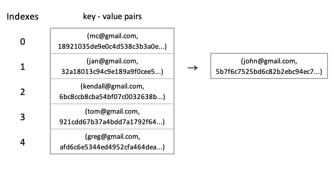

### 5. Data Structure:

- Hash tables
- Singly Linked list
- Dictionary

```python
import hashlib
import os
import binascii
import secrets
import string
import names
```

```python
#Create node class
class Node:
    def __init__(self, data, next_node = None):
        self.data = data
        self.next_node = next_node

#Create data class to store username, password
class Data:
    def __init__(self, username, password):
        self.username = username
        self.password = password

#create a HashTable class
class HashTable:

    def __init__(self,size):
        self.size = size
         #Initiate our hash table with empty values.
        self.hash_table = [None] * size

    #create a hashing function to return key for every value
    def Hashing(self, key):
        mult = 1
        hash_value = 0
        for i in key:
            hash_value += mult * ord(i)
            mult += 1
        return hash_value % self.size #ensure hash_value do not exceed the size of hash table


    #encode a provided password
    def make_password(self,password):
        #generate a random salt that will be added to the password
        salt = hashlib.sha256(os.urandom(60)).hexdigest().encode('ascii') #always return 64 characters long
        pwdhash = hashlib.pbkdf2_hmac('sha512', password.encode('utf-8'), salt, 100000)
        pwdhash = binascii.hexlify(pwdhash) #Return the hexadecimal representation of the binary data
        return (salt + pwdhash).decode('ascii')


    #verfiy if the plain text password provided by the user
    #matches the encoded password stored in the database
    def verify_password(self,stored_password, provided_password):
        #extract salt from the hashed password
        salt = stored_password[:64]
        #extract hash part of the  stored password
        stored_password = stored_password[64:]
        pwdhash = hashlib.pbkdf2_hmac('sha512', provided_password.encode('utf-8'), salt.encode('ascii'), 100000)
        pwdhash = binascii.hexlify(pwdhash).decode('ascii')
        return pwdhash == stored_password


    #add key value pair to hash table
    def add_username_password(self,username,password):

        hashed_password = self.make_password(password) #encode a provided password
        hashed_key = self.Hashing(username) #convert username into hash key

        if self.hash_table[hashed_key] is None: #if the index of hash key is none, add new node
            #add new node contains username and password
            self.hash_table[hashed_key] = Node(Data(username, hashed_password), None)
        else:
            #if there's already a node there, using chaining to avoid collision
            node = self.hash_table[hashed_key]
            while node.next_node: #stop when the next node is None
                node = node.next_node
            #add the new node to the end of the node
            node.next_node = Node(Data(username, hashed_password), None)

    #verify the username and password provided by users
    def verify_cred(self, username, password):
        hashed_key = self.Hashing(username)

        #check if the username exists in the hash table
        if self.hash_table[hashed_key] is not None:
            #retrieve the node stored in hash table
            node = self.hash_table[hashed_key]
            #check if only one node stored in this index
            if node.next_node is None:
                return self.verify_password(node.data.password, password)
            #if more than one node stored in this index, traverse the linked list
            while node.next_node:
                if username == node.data.username:
                    return self.verify_password(node.data.password, password)
                node = node.next_node
            #if the next node is not None (final node)
            if username == node.data.username:
                return self.verify_password(node.data.password, password)
        #if the username does not exists in the hash table
        print("User not found")


    #update password
    def update_password(self, username, password, password_new):
        hashed_key = self.Hashing(username)
        pwdhashed_new = self.make_password(password_new)

        if self.hash_table[hashed_key] is not None:
            node = self.hash_table[hashed_key]
            while (node.next_node is not None):
                if username == node.data.username:
                    stored_password = node.data.password
                    if self.verify_password(stored_password, password) == True:
                        node.data.password = pwdhashed_new
                    else:
                        raise Exception("Incorrect password")
                node = node.next_node

            if username == node.data.username:
                stored_password = node.data.password
                if self.verify_password(stored_password, password) == True:
                    node.data.password = pwdhashed_new
                else:
                    raise Exception("Incorrect password")

        else:
            print("User not found") #means can't find the key in the hash table


    def print_table(self):
        print("{")
        for i, val in enumerate(self.hash_table):
            if val is not None:
                llist_string = ""
                node = val
                if node.next_node:
                    while node.next_node:
                        llist_string += (
                            str(node.data.username) + ": " + str(node.data.password) + " ---> " +"\n"
                        )
                        node = node.next_node
                    llist_string += (
                        str(node.data.username) + ": " +str(node.data.password) + " ---> None"
                    )
                    print(f"  [{i}] {llist_string}")
                else:
                    print(f"  [{i}]{val.data.username}: {val.data.password}")

            else:
                print(f" [{i}]{val}")
        print("}")
```

```python
#generate random emails address with initial of first name and last name
def generate_email():
    first = names.get_first_name()[0].lower()
    last = names.get_first_name().lower()
    email = "@gmail.com"
    return (first + last +email)

    #string.ascii_letters: To include letters from a-z and A-Z
    #string.digits: To include digits from 1 to 10
    #string.punctuation: to get special symbols

#generate random passwords consist of letters, digits, and special symbols
def generate_password():
    alphabet = string.ascii_letters + string.digits + string.punctuation
    password = ''.join(secrets.choice(alphabet) for i in range(10))
    return password

#create a dictionary consist of the emails and password we just generated
def email_password(size):
    email = [generate_email() for i in range(size)]
    password = [generate_password() for i in range(size)]
    cred_dict = {key: value for key, value in zip(email, password)}
    return cred_dict
```

```python
cred_dict = email_password(10)
cred_dict
```

```
{'jleo@gmail.com': 'JEC:C13N-1',
 'padela@gmail.com': 'G8L.6Ul61J',
 'jnina@gmail.com': 'Tr&;RDQs[9',
 'efrank@gmail.com': '3Dcd)oPQ)<',
 'wjeromy@gmail.com': '-+b:}uP1CZ',
 'rraymond@gmail.com': 'x1?S!/{=uE',
 'atiffany@gmail.com': '""Ou6bG[%`',
 'pkristine@gmail.com': '.I\\^fTPST;',
 'glauren@gmail.com': '\\Z{8m({./J',
 'tlorraine@gmail.com': 'C3$=@JO]-J'}
```

```python
ht = HashTable(10)

#add username and password in the dictionary to the Hash Table
for key, value in cred_dict.items():
    ht.add_username_password(key, value)
```

```python
#print out the hash table
ht.print_table()
```

```
{
 [0]None
  [1]atiffany@gmail.com: f7a7c5520eb348383ddf6df0f267a4988e98313d8a396508d35d90577f22ead0e0dd64378811724a9919cb1f7aa73924f6d0955964ba5767a2f3e1165bbc26dec7bfb04776b79d311e157e418bedf1cfd6914b0cfd7bf2e969716d9f1a241218
  [2] jnina@gmail.com: 6040a8d7fddcf4ce3fc3e755ff0222ec8f11f0e653a7a6bfcf6622031712574a2ee3bb7054d87e137131f937ed4f1664ba136d8fe4c00647825b5a15175ebc65533331b59a49190d013ff798192476ac6ba4cddc1a46b14e769df94e4dbeb66a --->
glauren@gmail.com: 147d6601423c0afcdd2983af9593e868cc98dac363c16da66f42c3e07c097f2a02d0e4a94e346bd8126052b3a2f324e5851be5ae8457109f95c6bef1559dcf986d66f13ab6c109269bc0a6ca94566487b5391473f777e79f5b4a92da6ec88622 ---> None
  [3]pkristine@gmail.com: 809777b79e69ddc21e400dfc4a9dc923ba8fbf030d9c0e6f8211bba0bdd0daabcb123846d332b703eff6809088e147654edf86a8cf675e70db9e6ad9cdcc89dbaed14ab93c6d314e32ff2cc3c2739601ec33eb4632909ebad8c5f952764d687e
  [4] jleo@gmail.com: ca270def34967765bacff27a8eac3fcfe4a66e8fe31b224161a96bda1d92e698d39ef522285f5df4ab50035a142cfbe72e55998687c65325120f647e6300dc121e0607e5c09a2724c7773e5d86fdcb36ddf1e13d4bdc7ba72549f54a3d6b29ef --->
efrank@gmail.com: 5697949702618907c1e3d54b9f547c59cdb5ceecc8ebc69412da52883e1681ab1e95bee161dc9c3b9a858366f2e60f66a2b36a6cef91a340d773962f163363e28cfbed4ef057c3bf4aebc67a44753d149b7e8db0bd68ab3072f12824334ee79e --->
wjeromy@gmail.com: 441e71525cacc29af572bb276bf9f6077f231d44ed18d04a6d27d6570b0d03ef6fbcf6e2a09e50ed280bf0ddf31eba4d5e30d0b3ccdb1094f053f4f72921a24f717fc9e5df3bcfdff2edc5d61f69620f2f3af727ebc2e9277280f13fb8109056 ---> None
 [5]None
 [6]None
  [7] rraymond@gmail.com: 76e3b6d3368fbffe9951d55fcb83002c8f864cc2b696e08fd19db43d1618c97154615eb4bb5f087574ca1f9e700f9c205a751d0685112afdce5a893bb6756df4ee29d1c61a56826d1a81ac7c9a8632cca447e3f6966f8fb13da2b8b18f8e80e8 --->
tlorraine@gmail.com: e6c46e2d34a65af1da7afd7015f9cf62f956da6baec4ef9f7430e7e1e25e8ed784b3031f5c5cc1e526e7f3df3c500301b618b7290a1bc2264d2dcf57784cbddde82aa0b7324ac3ee1b8c99006d35153dcdc893a52f6a76a3c22ad6308d2ddafb ---> None
 [8]None
  [9]padela@gmail.com: 1cb8b1c78a49822bef9f9e4431b4f04b1d85db5cda3ebc4051427c2059ad61d55195ab9d9f74c7a27e6286b2cc304499e59ca6083a4189f47b578940101561b6d719cb255d94cbd7c1feab268eb43231c00affe6e4b192b42658bc3d89c64219
}
```

```python
#verify the username and password provided by the user
ht.verify_cred('jleo@gmail.com', 'JEC:C13N-1')
```

```
True
```

```python
ht.verify_cred('jleo@gmail.com', '123123')
```

```
False
```

```python
#update password
ht.update_password('jleo@gmail.com', 'JEC:C13N-1','123123')
```

```python
#verify username and password
ht.verify_cred('jleo@gmail.com', '123123')
```

```
True
```